# Seeds of Success - Diversity and impact of collections conserved in the USDA National Plant Germplasm System

Daniel Carver, Colin Khoury, Stephanie Greene, (potentially additional authors from Pullman, BLM)

June 22, 2018

**DRAFT**

- this is a working document
- at this stage the majority of the effort of the authors has been placed into developing a series of graphic/tables that alllows an exploration of the data (see results).
- The text within the document is preliminary and is expected to undergo major revisions based in part on input from outside contributors, as such much of the written content is merely an outline of what is to be expected.
- (from Colin- we need to provide a report to BLM. But for the academic paper, I personally think we should collaborate with BLM to talk about use in general including for restoration. This would be a much stronger paper, because overall the CWR and other useful plants aren’t that many)

# Abstract

Summarize the relationship between the BLM Seeds Of Success (SOS) program and the USDA ARS NPGS conservation efforts. These two organizations are collaborating on collecting, conserving, and making available for use a wide diversity of native plants occurring on public lands.

# 1 Introduction

The Seeds of Success (SOS) program was established in 2001 to facilitate the collection of native seeds. To make use of the collected materials, the program partners with land management agencies to support the re-vegetation of disturbed or degraded areas, academic and professional partners to promote and advance scientific research, and the United States Department of Agriculture (USDA) for the long term preservation of species genetic diversity.

The Seeds of Success program provides the boots on the ground effort in the collection of native seed, particularly for restoration. The program partners with the Agricultural Research Service of the USDA to store, maintain, and distribute the seeds collected. The Pullman, Washington section of the ARS is the group responsible for the initial on boarding and entering of the seeds into the Genetic Resource Inventory Network (GRIN) as well as maintaining the seeds in environments that support preservation.

This article provides an overview of the diversity of plants collected by the SOS program. It then examines the conservation of this diversity within the USDA Agricultural Research Service National Plant Germplasm System (NPGS) and the distribution of samples from the NPGS to researchers. Particular focus is given to crop wild relatives which are useful as genetic resources for the improvement of cultivated plants, and other species which have been used as sources of food, medicine, forage, and other purposes.

# 2 Methods

- data acquisition
  - SOS BLM: Information regarding the SOS collection was provided as a csv file by the Seeds of Success Program National Collection Curator in June of 2018. This dataset is continually updated as more field collecting occurs. All data from the years 2017 and earlier is assumed to be correct and complete. The data collected by the SOS program contains a rich set of specific information regarding the plant from which seed is collected as well as the geographic provenance and habitat that the plant was collected from. This dataset is made available by request only and can only be used with the express permission of the BLM SOS program.
  - GRIN Global : The NPGS’s Germplasm Resource Information Network(GRIN-Global) provides public access to informationa regardin accessions maintained by the System. The data is publicly available online. GRIN Global data for all SOS accessions were retrieved from the database by selecting all accessions that have an action_name_code of “SOS” and stored as csvs.
  - USDA ARS Pullman office: Before assessing the datasets a meeting of individuals involved with the management of the SOS accession was held to identify the primary questions, define the process of transferring the accessions between the agencies, and understand the processing and management of the collections once they enter the NPGS.
- data processing
  - rmarkdown : The datasets were processed, joined, and queried using the statistical programming language R. Specific libraries that were used include: plyr, tidyr, dplyr, and ggplot2. The report is compiled as an RMarkdown document to help with the reproducibility of the content as the relationship between the two organizations continues to develop.

# 3 Results

The results are split into sections based on the primary questions we attempted to answer. We should probably highlight the questions earily in the document but for now ther are listed here.

1. How diverse is the SOS collection?
2. How many of the SOS accessions can be identified as crop wild realtives (CWR), wild utilized species (WUS), and/or economically valuable plants (i.e. listed in GRIN World Economic Plants)?
3. What is the level of representation of SOS collections within the NPGS?
4. Where are SOS accessions curated within the NPGS?
5. What is the state of SOS collections in NPGS with regard to viability?
6. Who requests SOS accessions from NPGS and for what purposes?

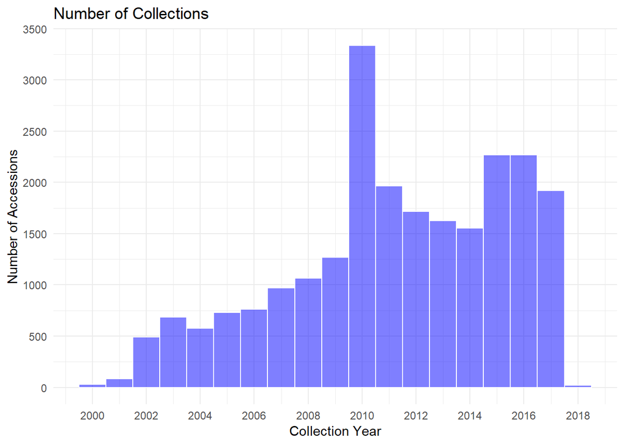

## 3.1 Diversity

|  | All Accessions | Total Number of Families | Total Number of Genera | Total Number of Taxa |
| --- | --- | --- | --- | --- |
| 1 | 23577 | 176 | 1153 | 5651 |

This Seeds of Success program since its inception has collected a total of 23577 accessions. These are comprised of 5651 unique taxa from 1153 genera from 176 plant families.

The [Flora of North America Association](http://floranorthamerica.org/Outreach/science_outreach) provides a published reference source that provides a comrehesive and systematic account of the plant species in North American North of Mexico.

> Species descriptions are written and reviewed by experts from the systematic botanical community worldwide, based on original observations of living and herbarium specimens supplemented by a crucial review of the literature. Each treatment includes scientific and common names, taxonomic descriptions, identification keys, distribution maps, illustrations, summaries of habitat and geographic ranges, pertinent synonomy, chromosome numbers, phenology, ethnobotanical uses and toxicity, and other relevant biological information. [FNA Introduction](http://floranorthamerica.org/introduction)

An accession is a sample of seeds from a single sampling location and in a single point in time. Collecting is performed, as possible, with the aim of harvesting enough seeds for short term storage, long term preservation, and for distribution.

|  | Family | Total Number of Accessions |
| --- | --- | --- |
| 1 | ASTERACEAE | 5303 |
| 2 | POACEAE | 4522 |
| 3 | CYPERACEAE | 1165 |
| 4 | FABACEAE | 1122 |
| 5 | SCROPHULARIACEAE | 1027 |
| 6 | ROSACEAE | 977 |
| 7 | CHENOPODIACEAE | 614 |
| 8 | APIACEAE | 585 |
| 9 | POLYGONACEAE | 582 |
| 10 | ONAGRACEAE | 434 |

[output cut: 166 more lines]

Out of the 176 families collected half of the total accessions collected come from just 5 families. These are among the most widespread and diverse plant families in the USA.

|  | Genera | Total Number of Accessions |
| --- | --- | --- |
| 1 | CAREX | 664 |
| 2 | POA | 512 |
| 3 | ACHNATHERUM | 510 |
| 4 | ERIOGONUM | 479 |
| 5 | PENSTEMON | 449 |
| 6 | ARTEMISIA | 423 |
| 7 | ELYMUS | 407 |
| 8 | ATRIPLEX | 379 |
| 9 | BOUTELOUA | 378 |
| 10 | JUNCUS | 316 |

[output cut: 1143 more lines]

This table shows the number of accession assocatied with the genera of all samples within the SOS data .

|  | Taxa | Total Number of Accessions |
| --- | --- | --- |
| 1 | Poa secunda | 445 |
| 2 | Achnatherum hymenoides | 337 |
| 3 | Elymus elymoides | 192 |
| 4 | Hesperostipa comata | 157 |
| 5 | Leymus cinereus | 130 |
| 6 | Bouteloua gracilis | 125 |
| 7 | Atriplex canescens | 103 |
| 8 | Artemisia tridentata ssp. wyomingensis | 93 |
| 9 | Koeleria macrantha | 92 |
| 10 | Panicum virgatum | 90 |

[output cut: 5641 more lines]

Table listing the number of collection for each speices. Most collected species are listed first.

## 3.2 Crop wild relatives, wild utilized species, and economic plants

Crop wild relatives are define in Maxted et al 2006 as

> A crop wild relative is a wild plant taxon that has an indirect use derived from its relatively close genetic relationship to a crop; this relationship is defined in terms of the CWR belonging to Gene Pools 1 or 2, or taxon groups 1 to 4 of the crop.

This defination is most commonly applied to species that support are food and agricultural systems it can be extened to incorporate species that are harvested for economic or cultural purposes such as ornamentals, medicial uses, and foresty. (Maxted et al 2006). These CWR contain a genictic diversity which has been used to improvepest and desease resistance, tolerance to abioticstress, inceased yield, novel cytoplasms, and quality traits to multiple major crop species.(Khoury et al 2013) Yet the limiting factor in the utilizaiton of CWR is the collection, preservation, and accessability of genetic information for research scientist (Harlan, 1976). While this statement was made in 1976 recent work has illistrated that is still a primary matter of concern. (FAO, 2010: Fowler and Hodgekin, 2004).

A recent inventory of U.S. crop wild relatives (Khoury et al. 2013) recognized 2500 taxa from 160 genera and 56 plant families. Of these, around 300 native species were prioritized as potentially highly useful relatives of important food crops. These include the wild cousins of crops that were domesticated by indigenous peoples in the United States, such as sunflower and squash, as well as more recent domesticates, such as blueberry, cranberry, raspberry, blackberry, and pecan. Other priority species include the northernmost relatives of Mesoamerican crops such as corn, bean, chili pepper, and cotton, as well as relatives of temperate crops first domesticated in Europe and Asia, such as onion, grape, apple, hops and walnut. If properly collected, conserved, and made accessible to crop scientists, these crop wild relatives will constitute an extremely diverse portfolio supporting present and future crop improvement efforts.

We utilized the K13 dataset because is was generated to be the “a primary step in the the process toward a national stategy for the conservation of CWRs”. The data sets makes an important distinstion between CWR and Wild Utilized Species(WUS. CWR are considered to be species that can directly be used for crop breeding. WUS are define by those that can be used for food, forage, medicine, herb, ornamental, and/or environmental restoration purposes. This extra level of distinction provides an import distinction regarding the intented use of the species. This dataset also provides a priority ranking system while allows for the identificantion of which species could have the greatest potential of crop genetic research. These details make this an ideal dataset for the interpretation of the true effect the SOS collections are having on the preservation of genetic resources.

The World Econmic Plants dataset is derived from the second edition of World Economic Plants: A Standard Reference (Wiersema, J., Leï¿½n, B., 2013.). This book is acts as a catalog of economic plants, maintaing a standard scientific names, common names, economic impacts, and geographic distribution. The book contains 312 families and 3,585 genera. Economic impacts are split into 16 primary classes and 113 subclasses. It is important to not that of the 16 primary classes 3 are mostly negitive in there ecomonic impacts. These economic classes have been incorperate by the [GRIN economic plant database](https://npgsweb.ars-grin.gov/gringlobal/taxon/taxonomysearcheco.aspx).

This study is using dataset complied by Khoury et al 2013 and Wiersema and Leon 2013 to identify species that are considered crop wild relatives (CWR) and/or wild utilized species (WUS) (Khoury et al. 2013), or economic plants (WEP). The chart below is defining the primary acronyms that are used in the remainder of this document

| Acronym | Meaning |
| --- | --- |
| SOS | Seeds of Success |
| GRIN | Germplasm Resource Information Network |
| NLGRP | National Laboratory Genetic Resource Presevation |
| WUS | Wild Utilized Species |
| K13 | Khoury et al 2013 |
| CWR | Crop Wild Relative |
| WEP | Economic Plant |

| CWR | NumberOfAccession | WUS | NumberOfAccession1 | WEP | NumberOfAccession2 |
| --- | --- | --- | --- | --- | --- |
| Poa secunda | 445 | Achnatherum hymenoides | 337 | Poa secunda | 445 |
| Elymus elymoides | 192 | Hesperostipa comata | 157 | Achnatherum hymenoides | 337 |
| Leymus cinereus | 130 | Bouteloua gracilis | 125 | Elymus elymoides | 192 |
| Atriplex canescens | 103 | Koeleria macrantha | 92 | Hesperostipa comata | 157 |
| Panicum virgatum | 90 | Eriogonum umbellatum | 88 | Leymus cinereus | 130 |
| Allium acuminatum | 82 | Purshia tridentata | 86 | Bouteloua gracilis | 125 |
| Pseudoroegneria spicata | 73 | Bouteloua curtipendula | 85 | Atriplex canescens | 103 |
| Atriplex confertifolia | 71 | Ericameria nauseosa | 84 | Koeleria macrantha | 92 |
| Elymus glaucus | 62 | Achillea millefolium | 84 | Panicum virgatum | 90 |
| Rosa woodsii | 52 | Balsamorhiza sagittata | 83 | Purshia tridentata | 86 |

[output cut: 10 more lines]

| label | SOS Collection |
| --- | --- |
| Total Accessions | 23577.0 |
| Total Number of Taxa | 5651.0 |
| Taxa that are CWR per K13 | 700.0 |
| Percent of SOS Accessions that are CWR per K13 | 12.4 |
| Accessions that are CWR per K13 | 4225.0 |
| Taxa that are WUS per K13 | 985.0 |
| Percent of SOS Accessions that are WUS per K13 | 17.4 |
| Accessions that are WUS per K13 | 8622.0 |
| Taxa that are WEP | 1081.0 |
| Percentage of SOS Accessions that are WEP | 19.1 |

[output cut: 1 more lines]

```r
###
# specifics for CWR priority 1a
##
cwr1a <- trimCombinedData %>%
  filter(Type == "CWR", Priority_specific2 == "Priority (1)A") %>%
  group_by(NAME) %>%
  dplyr::summarise(TotalAccession = n()) %>%
  dplyr::select(c("NAME", "TotalAccession"))%>%
  arrange(desc(TotalAccession))
cwr1a
```

| NAME | TotalAccession |
| --- | --- |
| Helianthus annuus | 43 |
| Helianthus petiolaris | 13 |
| Ilex opaca | 8 |
| Prunus emarginata | 8 |
| Vaccinium corymbosum | 7 |
| Lactuca floridana | 6 |
| Rubus leucodermis | 6 |
| Tripsacum dactyloides | 6 |
| Allium tricoccum | 5 |
| Fragaria virginiana | 5 |

[output cut: 49 more lines]

```r
totalP1A <- nrow(cwr1a)
```

This is a listing all all the Prioriety 1 A crop wild relatives. There are apporixmately 250 of these species in the United States. A P1A crop wild relative is a native species that is closely related to an important food crop. The SOS program has collected 59 of theses P1A species.

## 3.3 Conservation

The following table displays the diversity of SOS accessions that are currently maintained within the NPGS.

### 3.3.1 Accessions Stored Within the ARS System

The difference in the total number of accessions collected by SOS and the number of accessions recorded in GRIN is significant. Part of this can be explained by a potential backlog of samples within the ARS and a lag in delivery time between collection and distribution. It generally takes a year from when the seeds are collect to when they are received by the ARS. There is a lagtime between collecting seed and entrance into the system due to the work of processing seed and associated data. Not all SOS accesions make it into the NPGS (why? insufficient seed?)

| label | SOS Collection | SOS in GRIN Global |
| --- | --- | --- |
| Total Accessions | 23577.0 | 14767.0 |
| Total Number of Taxa | 5651.0 | 4088.0 |
| Taxa that are CWR per K13 | 700.0 | 586.0 |
| Percent of SOS Accessions that are CWR per K13 | 12.4 | 10.4 |
| Accessions that are CWR per K13 | 4225.0 | 2931.0 |
| Taxa that are WUS per K13 | 985.0 | 808.0 |
| Percent of SOS Accessions that are WUS per K13 | 17.4 | 14.3 |
| Accessions that are WUS per K13 | 8622.0 | 5464.0 |
| Taxa that are WEP | 1081.0 | 909.0 |
| Percentage of SOS Accessions that are WEP | 19.1 | 16.1 |

[output cut: 1 more lines]

Not all SOS collection make into GRIN as a result the proportion of the collection that is a CWR, WUS, or WEP decrease as well.

### 3.3.2 Accession Maintained at NLGRP for Long Term Backup

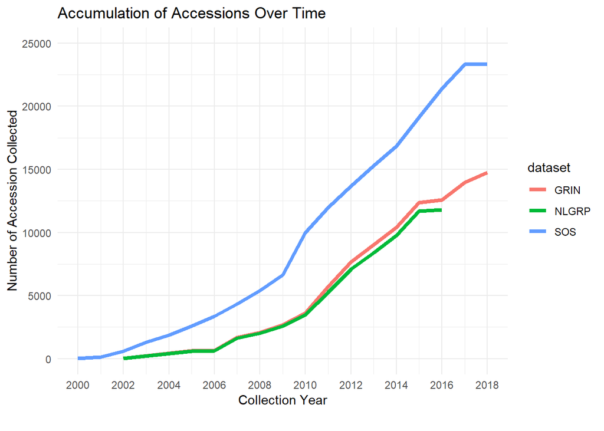

This illustrates that the rate of accumulation between the three groups fluctuates a bit over time. The drop in number of samples incorporated into GRIN and NLGRP in the more resent years is due in part to the time lag between data collecting, seed processing, and storage. It should also be noted that individual collection must have at least 10,000 un utilized seeds in order to be sent to the USDa for long term storage and distibution. SOS collections are gather with specific resporation porjects in mind at the district level. As a result often the seed gather is actively used for revegetation purposes. This is likely the most significant factor in the difference in samples collected and samples stored.

```
## [1] 3509
```

| label | SOS Collection | SOS in GRIN Global | SOS in NLGRP |
| --- | --- | --- | --- |
| Total Accessions | 23577.0 | 14767.0 | 11795.00 |
| Total Number of Taxa | 5651.0 | 4088.0 | 3509.00 |
| Taxa that are CWR per K13 | 700.0 | 586.0 | 510.00 |
| Percent of SOS Accessions that are CWR per K13 | 12.4 | 10.4 | 9.02 |
| Accessions that are CWR per K13 | 4225.0 | 2931.0 | 2315.00 |
| Taxa that are WUS per K13 | 985.0 | 808.0 | 732.00 |
| Percent of SOS Accessions that are WUS per K13 | 17.4 | 14.3 | 13.00 |
| Accessions that are WUS per K13 | 8622.0 | 5464.0 | 4431.00 |
| Taxa that are WEP | 1081.0 | 909.0 | 779.00 |
| Percentage of SOS Accessions that are WEP | 19.1 | 16.1 | 13.80 |

[output cut: 1 more lines]

Samples at NLGRP represent the most protected accessions. Most of the data that makes into the GRIN global system makes it in the backup system at NLGRP.

## 3.4 Where are SOS accessions Maintained in the NPGS?

The challenge of coordinating the preservation of these seeds is seen in part by how my samples become orphaned within the system, lacking a curator specialized in the pertinent genus or species. Orphaned accesions are those which do not fit into any of the existing collections. Orphaned accessions continue to be held at Pullman (W6) but without a formal curator. Note the Pullman quantities in the table include both curator and non curated accessions.

```r
# call in sosAccessions: summaries by maintaince site or owned by ***check with Colin or Renee on this one***
# produce a table showing number of successions and proportion of total


#group by location and derive number of taxon
sosAccTaxa <- grinData %>%
  group_by(Maintenance.Site) %>%
  dplyr::summarise(uniqueNumber = n_distinct(Taxon)) %>%
  dplyr::rename(Facility = "Maintenance.Site", UniqueTaxa = "uniqueNumber" )

library(plyr)
# subet columns needed.
sosOwner <- count(grinData$Maintenance.Site)%>%
  arrange(desc(freq))%>%
  dplyr::rename(Facility = x, NumberOfAccessions = freq)

####
# need to fix this a bit
####

  # mutate(FacilityName = c("Western Regional Plant Introduction Station, Washington", "Ornamental Plant Germplasm Center, Ohio", "National Animal Disease Center, Iowa",
  #                         "Plant Introduction Research, Iowa", "NSL unknown" , "Plant Genetic Resources Conservation Unit, Georgia", "SARU unknown Plants from alaska??", "Missing Data"))

#join the two datasets
sosOwner2 <- left_join(sosOwner, sosAccTaxa, by='Facility', type='left', match='all') %>%
  dplyr::rename(FacilityAcronym = "Facility")

# %>%
#   select(Facility, FacilityAcronym, NumberOfAccessions, UniqueTaxa)

sosOwner2
```

| FacilityAcronym | NumberOfAccessions | UniqueTaxa |
| --- | --- | --- |
| W6 | 10977 | 3052 |
| OPGC | 1569 | 662 |
| NC7 | 822 | 304 |
| S9 | 626 | 162 |
| NA | 441 | 174 |
| COR | 149 | 60 |
| PARL | 143 | 44 |
| NSSL | 25 | 13 |
| PALM | 9 | 8 |
| SYS | 3 | 3 |

[output cut: 2 more lines]

The majority of the SOS collection is maintained by the ARS in Pullman, Washington (W6). This is where the native plant collection is based. Accession that are maintained at other locations are there due to the request of other curators. The are accessions that are very unlikely to be orphaned. It is difficult to determine from data alone how many of the accession at W6 an being actively stored but not regenerated.

## 3.5 Viability of SOS seeds

Collection and storage are only part of the story. Germination and the ability to grow out the plant to collect new seeds is a large part of what the nPGS does. Often little is known about the conditions required to germinate the seeds.

An experiment was developed and performed by Annette Miller at the NLGRP. Annette tested the viability of seeds to germinate for 794 unique genera. This accounts for 68.86 percent of all the genera collected by the SOS program. The data generated by this study illustrates what to expect when working with these plants in the future. The table below shows that percentage of seeds that were tested that were successfully geminated. The histogram groups those into viability categories.

```r
colnames(viability) <- c('Genus', 'Percent_of_Viable_Sample' )
DT::datatable(arrange(viability, desc(Percent_of_Viable_Sample)))
```

|  | Genus | Percent_of_Viable_Sample |
| --- | --- | --- |
| 1 | Cosmos | 100 |
| 2 | Moehringia | 100 |
| 3 | Robinia | 100 |
| 4 | Zephyranthes | 100 |
| 5 | Phaseolus | 99.5 |
| 6 | Convolvulus | 99 |
| 7 | Alopecurus | 98 |
| 8 | Houstonia | 98 |
| 9 | Phryma | 98 |
| 10 | Selenia | 98 |

[output cut: 784 more lines]

The table shows the proportion of seeds received that were alive on arrival at NLGRP.

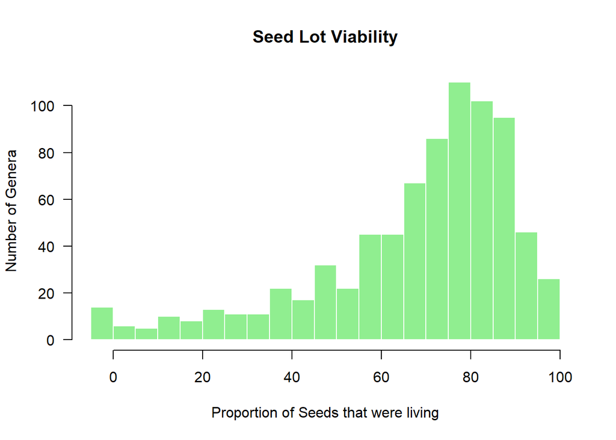

This distribution shows that the majority of the species collected by the SOS can be germinated given the current level of understanding. Species that had a very low germination success rate will require more research to understand what are the necessary conditions to promote successful germination. Until those methods are understood it may not be possible to maintain the population indefinitely.

## 3.6 Distribution of SOS Materials from the NPGS

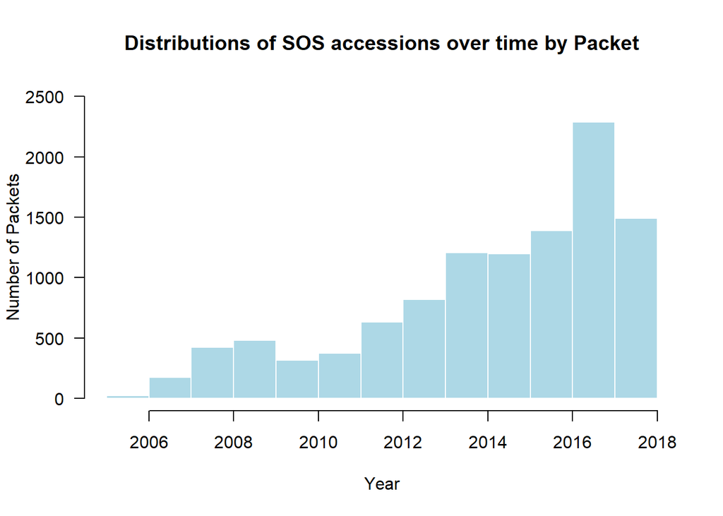

This is a graph of the total number of samples delivered. Each record is assocaited with approximately 100 seeds. While this represents a good description of the total number of seeds sent the chart below splits this data to examine the unique number of order request, the number of taxons order, and the number of accessions ordered per year.

```r
### need to remake a bargraph with a cumulative growth
### this will take some work

#create a count column for sos data
sosCount <- sosData %>%
  mutate(count = as.numeric(1))

sosCuml <- sosCount%>%
  group_by(COLL_YR) %>%
  dplyr::summarise(total = n())%>%
  mutate(dataset = 'SOS') %>%
  dplyr::rename(year = "COLL_YR") %>%
  mutate(cumsum = cumsum(total))


uniqueOrders <- date %>%
  select(year, order_request_id)%>%
  distinct() %>%
  group_by(year) %>%
  dplyr::summarise(count = n()) %>%
  mutate(use = "UniqueOrders") %>%
  dplyr::select(year,count,use) %>%
  mutate(cumsum = cumsum(count))


uniqueTaxon <- date %>%
  select(year, Taxon) %>%
  distinct() %>%
  group_by(year) %>%
  dplyr::summarise(count = n()) %>%
  mutate(use = "UniqueTaxon") %>%
  select(year,count,use) %>%
  mutate(cumsum = cumsum(count))


uniqueAccession <- date %>%
  select(year, accession_number) %>%
  distinct()  %>%
  group_by(year) %>%
  dplyr::summarise(count = n()) %>%
  mutate(use = "UniqueAccession") %>%
  select(year,count,use)  %>%
  mutate(cumsum = cumsum(count))

uniquePacket <- date %>%
  select(year) %>%
  group_by(year) %>%
  dplyr::summarise(count = n()) %>%
  mutate(use = "UniquePacket") %>%
  select(year,count,use)  %>%
  mutate(cumsum = cumsum(count))

allGroups <- rbind(uniqueOrders, uniqueTaxon,uniqueAccession ,uniquePacket)
allGroups
```

| year | count | use | cumsum |
| --- | --- | --- | --- |
| 2005 | 1 | UniqueOrders | 1 |
| 2006 | 2 | UniqueOrders | 3 |
| 2007 | 52 | UniqueOrders | 55 |
| 2008 | 122 | UniqueOrders | 177 |
| 2009 | 108 | UniqueOrders | 285 |
| 2010 | 114 | UniqueOrders | 399 |
| 2011 | 142 | UniqueOrders | 541 |
| 2012 | 179 | UniqueOrders | 720 |
| 2013 | 220 | UniqueOrders | 940 |
| 2014 | 235 | UniqueOrders | 1175 |

[output cut: 46 more lines]

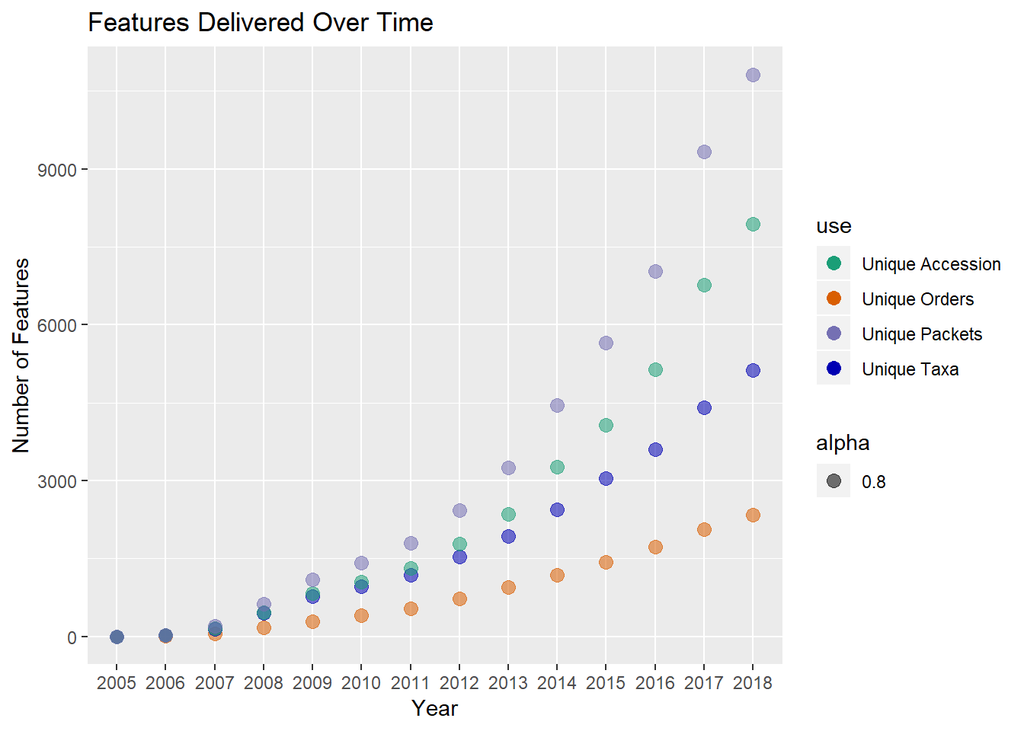

```r
ggplot(allGroups, aes(x=year,  y=cumsum, color = use, alpha=0.8)) +
  geom_point(size=3)+
  labs(x="Year", y="Number of Features", title = 'Features Delivered Over Time') +
  scale_color_manual(labels = c("Unique Accession","Unique Orders", "Unique Packets","Unique Taxa") , values=c("#1b9e77","#d95f02","#7570b3", "#0000b3"))
```

The NPGS stores and distributes to researchers accesions that collected by SOS. Seeds are distributed for a number of reasons including academic research studies and educational demonstrations. Many of the distributions take place within the ARS when seeds are sent to and from various seed labs (CK - ???). The distribution of seeds is end user driven and a result the volume of seeds transferred fluctuates over time.

| Reason for Distribution | Individual Packets |
| --- | --- |
| NA | 5698 |
| RESEARCH | 4236 |
| EDUCATION | 570 |
| OTHER | 310 |
| HOME | 6 |

Primary reason for distibution was incorperated into the ordering process in 2015. There are four drop down options.

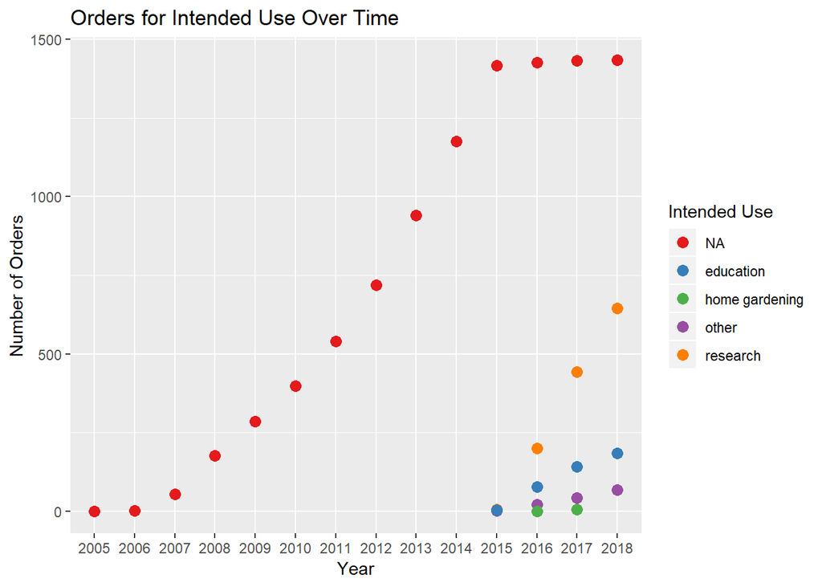

If we take a look at the deliveries over time we can see there is some distinct variability over time. The NA variable is present because before 2015 the reason for distribution was not recorded.

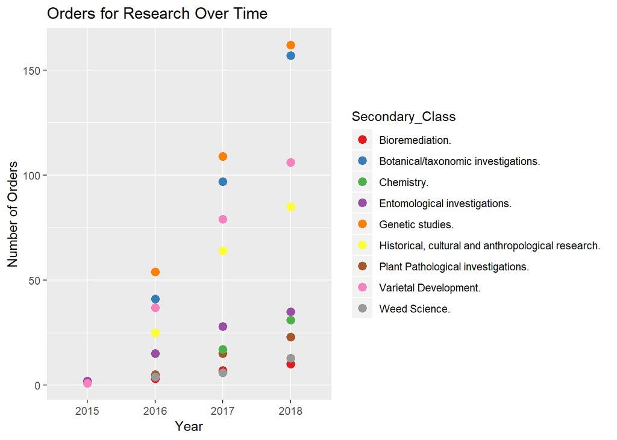

The research catergory has 9 distinct secondary classes. Their relative abundence is illistrated by the graph above.

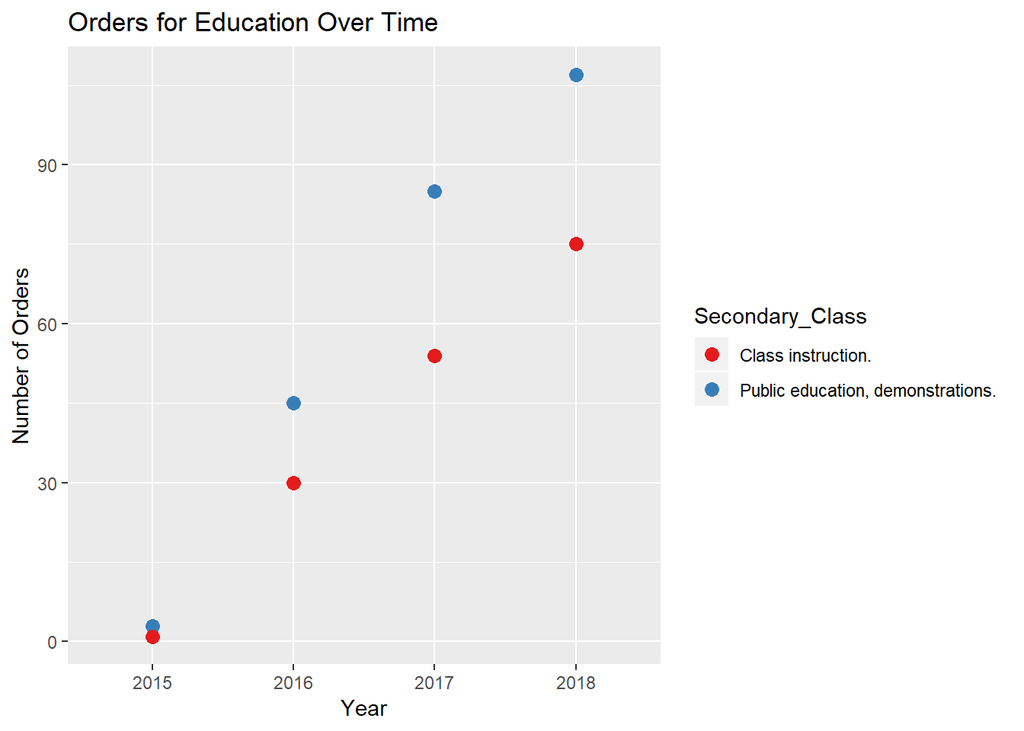

The Education catergory has 2 distinct secondary classes. Their relative abundence is illistrated by the graph above.

The other and home gardening class do not have a standardize secondary class. Similarily all orders occur before 2015 do not have any standarized classifacation. Users requestiong orders would fill out the need for the order in a notes column on the request form. This notes column was combined with the class columns for orders after 2015. In order to pull some generalized information from this notes columb we employed some text mininng techniques to find commonly used words.

|  | Word | Number.of.Occurances | process |
| --- | --- | --- | --- |
| 1 | plant | 815 | 0 |
| 2 | use | 650 | 1 |
| 3 | seed | 518 | 0 |
| 4 | studies | 403 | 1 |
| 5 | research | 381 | 1 |
| 6 | species | 356 | 0 |
| 7 | garden | 332 | 0 |
| 8 | grow | 258 | 1 |
| 9 | phaseolus | 236 | 0 |
| 10 | native | 216 | 0 |

[output cut: 223 more lines]

The table above illustate all words that have occur over 30 times in the written notes of the orders. Notes are not required for orders and while it can be assumed that the number of times a word appears is positively related to the number of orders it appear in not efforts were made to not count words repeated used in a single order. The full list of words contians information about what was to be done with the order and details about the order itself( what species). To distiguish between the tool we accessed if the word was associated with a process or not. In the table above 1 indicates the world is related to a process, 0 does not. We generated specific word clounds based on these two groups.

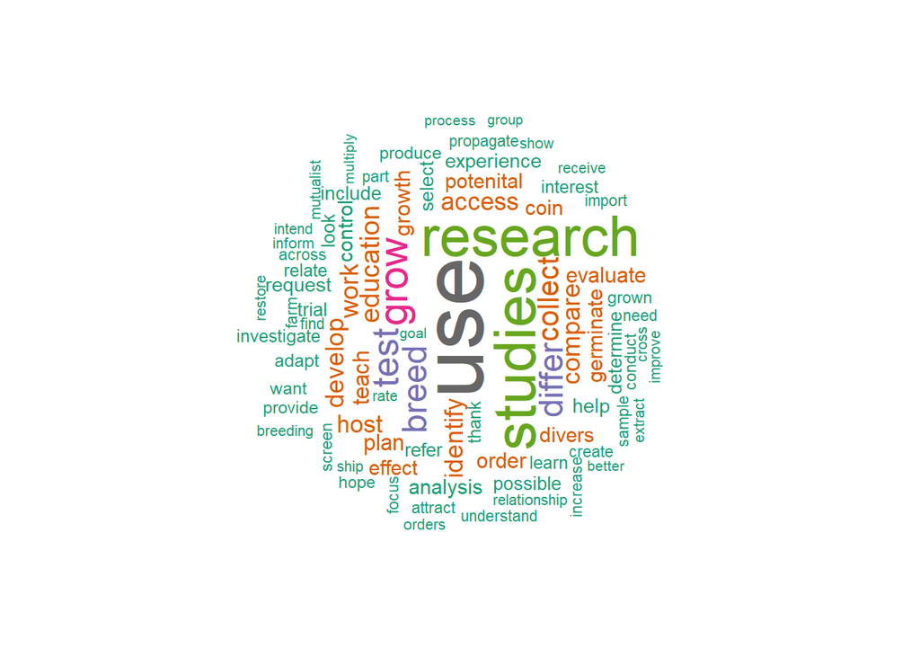

word cloud displaying all the process related words

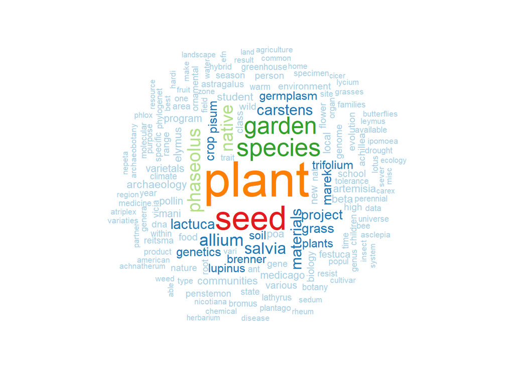

A word cloud displaying all non process related words.

|  | intended_use_code | Secondary_Class | qualData |
| --- | --- | --- | --- |
| 1 | RESEARCH | Weed Science. | - We are examining germination characteristics and genetics of plant species that are native to Europe, but invasive in the US or native in the US (such as Juncus tenuis) and invasive in Europe to bet… |
| 2 | RESEARCH | Weed Science. | - This research project involves growing animal friendly plants for landscaping purposes and soil erosion___ |
| 3 | RESEARCH | Weed Science. | - The accessions will be used in a common garden experiment to test whether invasive-range Solidago canadensis accessions in China have evolved a higher competitive ability than native-range S. canade… |
| 4 | RESEARCH | Weed Science. | - Testing fungal communities with different plant species.___ |
| 5 | RESEARCH | Weed Science. | - Study the effects on soil erosion and improvement of soil quality with minimal effort. I.E. which species offer greatest protection against soil erosion with minimal care. ___ |
| 6 | RESEARCH | Weed Science. | - Study of herbicide effect on biological soil crusts, native and non-native plants, and crust effect on plants. ___ |
| 7 | RESEARCH | Weed Science. | - Students will be conducting studies examining latitudinal gradients in competitive abilities and herbivore defenses, comparing the effects of competition and nitrogen availability on modern and ance… |
| 8 | RESEARCH | Weed Science. | - Species correlation with fungi.___ |
| 9 | RESEARCH | Weed Science. | - planning to study the effect of these weeds on fish___ |
| 10 | RESEARCH | Weed Science. | - planning to study the effect of these weeds on fish___ |

[output cut: 635 more lines]

This table contains a complete listing of all the user inputs regarding what they attended to use the seeds for.

|  | Entity Receiving Seeds | Number Of Genera Received | Samples Distributed |
| --- | --- | --- | --- |
| 1 |  | 189 | 778 |
| 2 | , Hacienda Heights, California, USA | 86 | 127 |
| 3 | Washington State University, Pullman, Washington, USA | 79 | 229 |
| 4 | Rensselaer Polytechnic Institute, Troy, New York, USA | 78 | 90 |
| 5 | Desert Research Institute, Reno, Nevada, USA | 77 | 135 |
| 6 | Department of Anthropology, Texas A&amp;M University, College Station, Texas, USA | 43 | 72 |
| 7 | Watershed Garden Works, Longview, Washington, USA | 41 | 110 |
| 8 | New Mexico State Univ., Las Cruces, New Mexico, USA | 40 | 147 |
| 9 | Newcastle University, Newcastle upon Tyne, England, GBR | 39 | 56 |
| 10 | Delaware State University, Dover, Delaware, USA | 35 | 85 |

[output cut: 1079 more lines]

This table shows the locations that are receiving the most SOS seeds. The number of unique genera delivered and the number of packets distributed are both shown.

|  | Taxon | Total Packets Delivered | Total Accessions Pulled From |
| --- | --- | --- | --- |
| 1 | Achnatherum hymenoides | 245 | 124 |
| 2 | Salvia columbariae | 153 | 25 |
| 3 | Achillea millefolium | 106 | 46 |
| 4 | Pseudoroegneria spicata | 98 | 38 |
| 5 | Poa secunda | 90 | 46 |
| 6 | Koeleria macrantha | 83 | 50 |
| 7 | Linum lewisii | 79 | 19 |
| 8 | Elymus elymoides | 76 | 63 |
| 9 | Asclepias speciosa | 71 | 12 |
| 10 | Poa fendleriana | 69 | 36 |

[output cut: 1939 more lines]

This chart shows the number of times a specific taxon has been delivered. These deliveries could include multiple accessions.

|  | Category Code | Total Unique Taxon Received | Total Orders | Total Packets |
| --- | --- | --- | --- | --- |
| 1 | STA | 1378 | 953 | 4472 |
| 2 | FPRU | 583 | 332 | 1421 |
| 3 | UCOM | 732 | 307 | 1415 |
| 4 | UIND | 657 | 434 | 1410 |
| 5 | UPRU | 431 | 132 | 1018 |
| 6 | FCOM | 256 | 89 | 680 |
| 7 | UFED | 136 | 48 | 287 |
| 8 | FIND | 36 | 15 | 66 |
| 9 | FGEN | 41 | 27 | 49 |

This graphic shows which user group is receiving the greatest diversity of taxa.

# 4 Discussion

- there is a lot of room for narrative and exploration of these results. Collaboration with individuals more involved in the processing of these accession need to be pulled in to provide opinions and highlight significance of results per each section

# 5 Extras (just ideas really)

The SOS data contains a wealth of information regarding the environment surrounding the collection sites. Depending on the interest and direction of this document, there are alot of interesting routes this data can lead.

One idea we tossed around a bit it showcasing a specific species in more detail. For example Heliantheis Annus is the most collected P1A CWR. This could entail a map of collection site or a showcase of the plants that are present around this species.

The table show all the species associated with the the collection site.

|  | PHYTOREGION_FULL | sp1 | sp2 | sp3 | sp4 | sp5 | sp6 | sp7 | sp8 | sp9 | sp10 | sp11 | sp12 | sp13 | sp14 | sp15 | sp16 |
| --- | --- | --- | --- | --- | --- | --- | --- | --- | --- | --- | --- | --- | --- | --- | --- | --- | --- |
| 1 | Arizona/New Mexico Mountains (Omernik) | Pinus ponderosa | Bouteloua gracilis | Gutierrezia sarothrae | Bahia dissecta |  |  |  |  |  |  |  |  |  |  |  |  |
| 2 | Arizona/New Mexico Plateau (Omernik) | Artemisia tridentata | Artemisia frigida | Gutierrezia sarothrae | Ericameria greenei | Melilotus sp. | Asclepias subverticillata | Juniperus monosperma | Pinus edulis | Heterotheca villosa | Bouteloua gracilis | Agropyron cristatum |  |  |  |  |  |
| 3 | Arizona/New Mexico Plateau (Omernik) | Gutierrezia sarothrae | Artemisia tridentata | Bouteloua curtipendula |  |  |  |  |  |  |  |  |  |  |  |  |  |
| 4 | Arizona/New Mexico Plateau (Omernik) | Gutierrezia sarothrae | Poa pratensis | Atriplex canescens | Bouteloua gracilis | Krascheninnikovia lanata |  |  |  |  |  |  |  |  |  |  |  |
| 5 | Arizona/New Mexico Plateau (Omernik) | Psathyrostachys juncea | Lysimachia nummularia | Tragopogon dubius | Kochia scoparia | Bromus tectorum | Elymus elymoides | Salsola sp. |  |  |  |  |  |  |  |  |  |
| 6 | Arizona/New Mexico Plateau (Omernik) | Gutierrezia sarothrae | Poa pratensis | Atriplex canescens | Boerhavia gracillima | Krascheninnikovia lanata |  |  |  |  |  |  |  |  |  |  |  |
| 7 | Blue Mountains (Omernik) | Artemisia tridentata ssp. tridentata | Agropyron cristatum | Bromus tectorum | Sporobolus cryptandrus | Sisymbrium sp. | Lactuca serriola |  |  |  |  |  |  |  |  |  |  |
| 8 | Central Basin and Range (Omernik) | Salicornia sp. | Apocynum cannabinum | Tamarix chinensis | Distichlis spicata |  |  |  |  |  |  |  |  |  |  |  |  |
| 9 | Central Basin and Range (Omernik) | Poa secunda | Distichlis spicata | Sarcobatus vermiculatus | Bassia hyssopifolia |  | Tamarix sp. | Bromus tectorum | Apocynum cannabinum | Asclepias sp. | Phragmites sp. | Chrysothamnus viscidiflorus | Carex sp. |  | Cordylanthus maritimus | Centaurium exaltatum |  |
| 10 | Central Basin and Range (Omernik) | Bromus tectorum | Ericameria nauseosa |  |  |  |  |  |  |  |  |  |  |  |  |  |  |

[output cut: 33 more lines]

The table shows all the species associated with the the collection site. It can be filtered to show varied phytoregion. I think this is very interesting for understanding potential genetic diversity across the landscape.

[interactive chart not shown]

**use arrows to move around the map… A little odd sorry** Very basic map, but could offer some opportunity to highlight collection within a specific regions (sagebrush habitat), Recent burned areas. Again just lots and lots of possabilities.

*work on adding the reference into the text when appropriate.*

Maxted et al. (2006)

Khoury et al. (2013)

Harlan (1976)

(“FLORA OF NORTH AMERICA - Introduction Flora of North America” n.d.)

Genetic Resources for Food and Agriculture (2010)

# 6 References

Found out how to make this work!!! You need to add the intext reference by @ + reference call from the bib file. If it is cited within the paper the full reference will be added to the doc. What’s nice about this is that you can pull from a bit .bib file and only reference specific papers from it.

“FLORA OF NORTH AMERICA - Introduction Flora of North America.” n.d. Accessed September 26, 2018. http://floranorthamerica.org/introduction.

Genetic Resources for Food and Agriculture, Commission on, ed. 2010. *The Second Report on the State of the World’s Plant Genetic Resources for Food and Agriculture*. Rome: Commission on Genetic Resources for Food; Agriculture, Food; Agriculture Organization of the United Nations.

Harlan, Jack. R. 1976. “Genetic Resources in Wild Relatives of Crops1.” *Crop Science* 16 (3):329. https://doi.org/10.2135/cropsci1976.0011183X001600030004x.

Khoury, Colin K., Stephanie Greene, John Wiersema, Nigel Maxted, Andy Jarvis, and Paul C. Struik. 2013. “An Inventory of Crop Wild Relatives of the United States.” *Crop Science* 53 (4):1496. https://doi.org/10.2135/cropsci2012.10.0585.

Maxted, Nigel, Brian V. Ford-Lloyd, Stephen Jury, Shelagh Kell, and Maria Scholten. 2006. “Towards a Definition of a Crop Wild Relative.” *Biodiversity and Conservation* 15 (8):2673–85. https://doi.org/10.1007/s10531-005-5409-6.